# Variant filtering

Discuss different types of relevant filters, e.g.

- filtering on read depth, both high to eliminate collapsed repeats, and low for mappability issues. This is particularly important for incomplete assemblies

### Intended learning outcomes

- create per-sample and total depth of coverage profiles
- generate mask files for downstream processing

### Tools

- mosdepth (Pedersen & Quinlan, 2018)
- [d4-tools](https://github.com/38/d4-format) (Hou et al., 2021)
- samtools (Danecek et al., 2021)
- [csvtk](https://bioinf.shenwei.me/csvtk/)
- [bedtools](https://bedtools.readthedocs.io/en/latest/index.html) (Quinlan & Hall, 2010)

### Input data

We will be working with the Out of Africa dataset, consisting of 10 samples from the CEU, CHB, and YRI populations. The input consists of 10 bam files:

```bash
ls -lLh *.bam
```

```
-rw-r--r-- 1 runner docker 7.8M Dec 17 12:45 CEU-1.ooa.chr21.bam
-rw-r--r-- 1 runner docker 6.3M Dec 17 12:45 CEU-2.ooa.chr21.bam
-rw-r--r-- 1 runner docker 4.8M Dec 17 12:45 CEU-3.ooa.chr21.bam
-rw-r--r-- 1 runner docker  13M Dec 17 12:45 CEU-4.ooa.chr21.bam
-rw-r--r-- 1 runner docker 5.8M Dec 17 12:45 CHB-1.ooa.chr21.bam
-rw-r--r-- 1 runner docker 5.2M Dec 17 12:45 CHB-2.ooa.chr21.bam
-rw-r--r-- 1 runner docker 6.5M Dec 17 12:45 CHB-3.ooa.chr21.bam
-rw-r--r-- 1 runner docker 6.1M Dec 17 12:45 YRI-1.ooa.chr21.bam
-rw-r--r-- 1 runner docker 6.0M Dec 17 12:45 YRI-2.ooa.chr21.bam
-rw-r--r-- 1 runner docker 7.6M Dec 17 12:45 YRI-3.ooa.chr21.bam
```

## Coverage analyses

Reasons may vary but include uneven mapping coverage due to repeat regions, low coverage due to mis-assemblies, or coverage biases generated in the sequencing process. Importantly, both variable and monomorphic sites must be treated identically in the filtering process to avoid selection biases.

In this part, we will use `mosdepth` and `d4tools` to quickly generate depth of coverage profiles of mapped data. `mosdepth` is an ultra-fast command line tool for calculating coverage from a bam file. It can output results in a highly compressed format `d4`, which has been developed to handle the ever increasing size of resequencing projects. Files in d4 format can be processed with the `d4tools` tool.

### Per-sample coverage

We start by calculating per-sample coverages with `mosdepth`. For downstream purposes, we need to save the size of the chromosomes we’re looking at:

```bash
samtools view CEU-1.ooa.chr21.bam -H | grep SQ | awk '{OFS="\t";print $2, $3}' | sed -e "s/[SNL:]//g" > genome.txt
```

The syntax to generate coverage information for a bam file is `mosdepth <prefix> <input file>`. Here, we add the `--d4` option to generate d4 output and exclude reads with a mapping quality less than 20 (`-Q` flag):

```bash
mosdepth -Q 20 --d4 CEU-1 CEU-1.ooa.chr21.bam
```

The d4 output file will be named `CEU-1.per-base.d4` and can be viewed with `d4tools` to generate `bed` representation of the coverage:

```bash
d4tools view CEU-1.per-base.d4 | head -n 5
```

```
chr21   0   7   0
chr21   7   22  1
chr21   22  45  2
chr21   45  47  3
chr21   47  54  4
```

To get an idea of what the coverage looks like over the chromsome, we can use `bedtools` and `cvstk` in a one-liner to generate a simple coverage plot (Figure 1)[^1].

```bash
bedtools intersect -a <(bedtools makewindows -g genome.txt -w 5000) \
         -b <(d4tools view CEU-1.per-base.d4) -wa -wb | \
    bedtools groupby -i - -g 1,2,3 -c 7 -o mean | \
    csvtk plot -t line -x 2 -y 4 --point-size 0.01 --xlab Position \
          --ylab Coverage --width 9.0 --height 3.5 > fig-plot-coverage.png
```

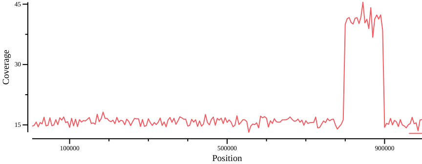

Figure 1: Coverage for sample CEU-1 in 5kb windows. Experiment changing the window size (`-w`) parameter to change smoothing.

Apparently there are some high-coverage regions that could be associated with, e.g., collapsed repeat regions in the assembly. Let’s compile coverage results for all samples.

```bash
for f in *.bam; do
    mosdepth -Q 20 --d4 ${f%.ooa.chr21.bam} $f
    echo -e -n "${f%.ooa.chr21.bam}\t"
    cat ${f%.ooa.chr21.bam}.mosdepth.summary.txt | grep total
done
```

```
CEU-1   total   1000000 17917183    17.92   0   68
CEU-2   total   1000000 14292139    14.29   0   67
CEU-3   total   1000000 10428655    10.43   0   52
CEU-4   total   1000000 30572047    30.57   0   115
CHB-1   total   1000000 12830597    12.83   0   62
CHB-2   total   1000000 11392259    11.39   0   52
CHB-3   total   1000000 14835251    14.84   0   60
YRI-1   total   1000000 13699799    13.70   0   63
YRI-2   total   1000000 13437937    13.44   0   59
YRI-3   total   1000000 17218621    17.22   0   69
```

## References

Danecek, P., Bonfield, J. K., Liddle, J., Marshall, J., Ohan, V., Pollard, M. O., Whitwham, A., Keane, T., McCarthy, S. A., Davies, R. M., & Li, H. (2021). Twelve years of SAMtools and BCFtools. *GigaScience*, *10*(2), giab008. https://doi.org/10.1093/gigascience/giab008

Hou, H., Pedersen, B., & Quinlan, A. (2021). Balancing efficient analysis and storage of quantitative genomics data with the D4 format and D4tools. *Nature Computational Science*, *1*(6), 441–447. https://doi.org/10.1038/s43588-021-00085-0

Li, H. (2014). Toward better understanding of artifacts in variant calling from high-coverage samples. *Bioinformatics*, *30*(20), 2843–2851. https://doi.org/10.1093/bioinformatics/btu356

Pedersen, B. S., & Quinlan, A. R. (2018). Mosdepth: Quick coverage calculation for genomes and exomes. *Bioinformatics*, *34*(5), 867–868. https://doi.org/10.1093/bioinformatics/btx699

Quinlan, A. R., & Hall, I. M. (2010). BEDTools: A flexible suite of utilities for comparing genomic features. *Bioinformatics*, *26*(6), 841–842. https://doi.org/10.1093/bioinformatics/btq033

## Footnotes

[^1]: The one-liner combines the results of several commands in a pipe stream. Also, [Bash redirections](https://www.gnu.org/software/bash/manual/html_node/Redirections.html) are used to gather the results from the output of `bedtools makewindows` and `dftools view` to `bedtools intersect`. The intersection commands collects coverage data in 5kb windows that are then summarized by `bedtools groupby`.